# PROJET D’ANALYSE DE DONNÉES

Analyse en Composantes Principales (ACP) et Méthodes de Classification sur la Satisfaction des Recommandations Algorithmiques

Zeineb Saidani, Fares Selmi

10 May 2026

# Introduction

## Contexte de l’étude

Dans l’ère numérique actuelle, les systèmes de recommandation basés sur des algorithmes complexes sont omniprésents. Que ce soit sur les plateformes de streaming comme Netflix et Spotify, ou sur les réseaux sociaux comme Instagram et TikTok, ces outils façonnent nos choix et nos habitudes de consommation.

Cette étude vise à analyser la perception et la satisfaction des utilisateurs face à ces recommandations. L’objectif est de comprendre si les utilisateurs se sentent compris par ces algorithmes, s’ils leur font confiance, et comment leurs caractéristiques démographiques influencent ces perceptions.

## Objectifs du projet

L’objectif principal est de mettre en œuvre une démarche complète d’analyse de données multidimensionnelles :

1. **Statistiques Descriptives** : Portrait global de l’échantillon.
2. **ACP** : Réduction de dimensionnalité et identification des axes de perception majeurs.
3. **ACM** : Étude des relations entre les variables qualitatives et comportements binaires.
4. **HCPC & K-means** : Segmentation des individus en profils types.

## Présentation des données

```r
data <- read.csv("Votre avis sur la formation (réponses) - Réponses au formulaire 1.csv",
                 header = TRUE)
rownames(data) <- 1:nrow(data)
```

Le jeu de données est issu d’un questionnaire administré en 2026, récoltant **45 réponses**. Il comprend des variables démographiques (Age, Sexe, Niveau d’étude), des variables d’usage (Fréquence, Plateformes), 24 questions sur échelle de Likert (Q7 à Q30) et 5 questions binaires (Q31-Q35).

# Statistiques Descriptives

## Répartition sociodémographique

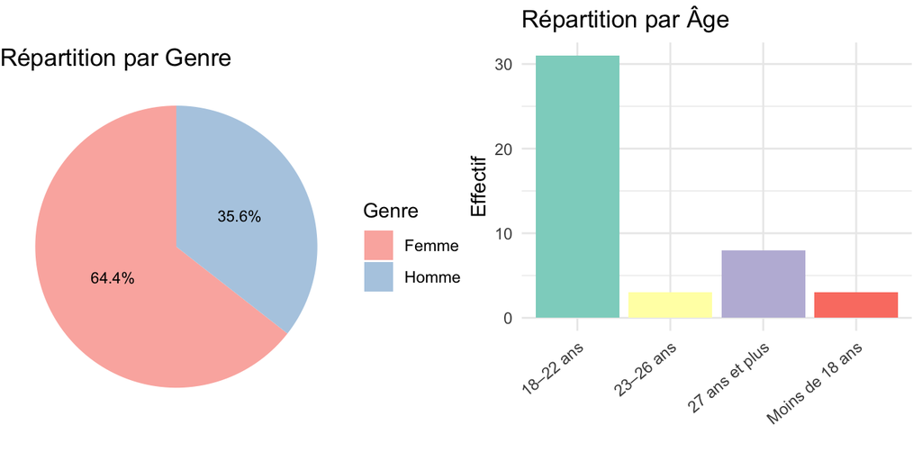

```r
# Genre
sexe_freq <- as.data.frame(table(data$Q3))
colnames(sexe_freq) <- c("Genre", "Effectif")
p1 <- ggplot(sexe_freq, aes(x = "", y = Effectif, fill = Genre)) +
  geom_bar(stat = "identity", width = 1) +
  coord_polar("y", start = 0) + theme_void() +
  scale_fill_brewer(palette = "Pastel1") +
  labs(title = "Répartition par Genre") +
  geom_text(aes(label = paste0(round(Effectif/sum(Effectif)*100, 1), "%")),
            position = position_stack(vjust = 0.5), size = 3)

# Âge
age_freq <- as.data.frame(table(data$Q2))
colnames(age_freq) <- c("Tranche_Age", "Effectif")
p2 <- ggplot(age_freq, aes(x = Tranche_Age, y = Effectif, fill = Tranche_Age)) +
  geom_bar(stat = "identity") + theme_minimal() +
  scale_fill_brewer(palette = "Set3") +
  labs(title = "Répartition par Âge", x = "", y = "Effectif") +
  theme(axis.text.x = element_text(angle = 40, hjust = 1), legend.position = "none")

gridExtra::grid.arrange(p1, p2, ncol = 2)
```

**Interprétation :** La majorité des répondants sont jeunes (18-26 ans), cohérent avec une étude sur les algorithmes de réseaux sociaux largement utilisés par la Gen Z.

## Niveau d’étude et Fréquence d’utilisation

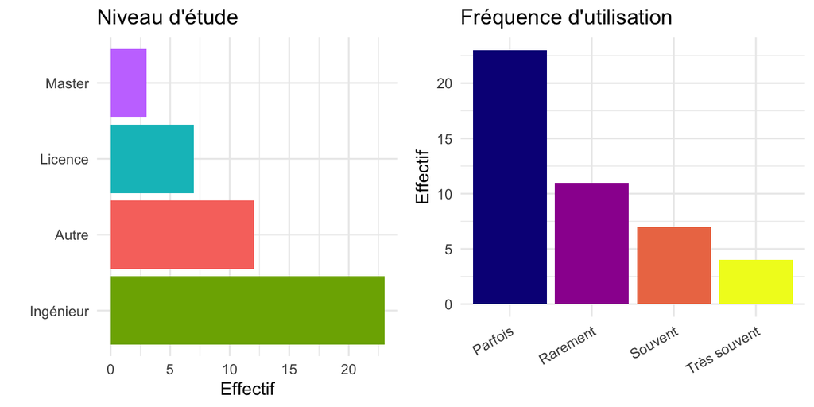

```r
# Niveau d'étude
etude_freq <- as.data.frame(table(data$Q4))
colnames(etude_freq) <- c("Niveau", "Effectif")
p3 <- ggplot(etude_freq, aes(x = reorder(Niveau, -Effectif), y = Effectif, fill = Niveau)) +
  geom_bar(stat = "identity") + theme_minimal() +
  labs(title = "Niveau d'étude", x = "", y = "Effectif") +
  coord_flip() + guides(fill = "none")

# Fréquence
freq_usage <- as.data.frame(table(data$Q5))
colnames(freq_usage) <- c("Frequence", "Effectif")
p4 <- ggplot(freq_usage, aes(x = Frequence, y = Effectif, fill = Frequence)) +
  geom_bar(stat = "identity") + theme_minimal() +
  labs(title = "Fréquence d'utilisation", x = "", y = "Effectif") +
  scale_fill_viridis_d(option = "plasma") +
  theme(axis.text.x = element_text(angle = 30, hjust = 1), legend.position = "none")

gridExtra::grid.arrange(p3, p4, ncol = 2)
```

## Plateformes les plus utilisées

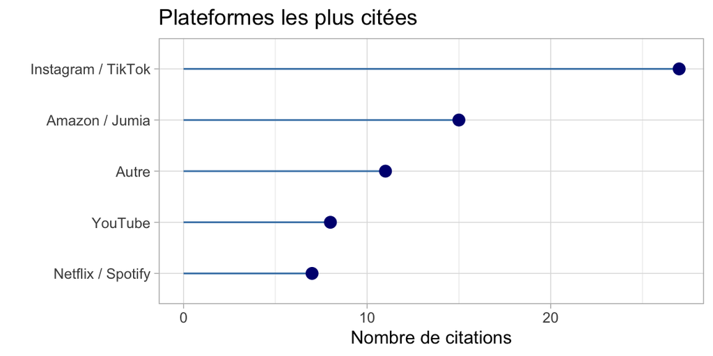

```r
plats <- data$Q6 %>% strsplit(", ") %>% unlist() %>% table() %>% as.data.frame()
colnames(plats) <- c("Plateforme", "Frequence")

ggplot(plats, aes(x = reorder(Plateforme, Frequence), y = Frequence)) +
  geom_segment(aes(xend = Plateforme, y = 0, yend = Frequence), color = "steelblue") +
  geom_point(color = "navy", size = 3) + theme_light() + coord_flip() +
  labs(title = "Plateformes les plus citées", x = "", y = "Nombre de citations")
```

# Analyse en Composantes Principales (ACP)

L’ACP est une méthode de réduction de dimensionnalité qui transforme des variables corrélées en composantes principales décorrélées. Nous utilisons ici `FactoMineR` sur les 24 variables de satisfaction (Q7–Q30), avec les variables démographiques en illustratives.

```r
res.pca <- PCA(data,
               quanti.sup = NULL,
               quali.sup = c(1, 2, 3, 4, 5, 6, 31:35),
               graph = FALSE)
```

## Matrice de corrélation

Avant de retenir l’ACP, il convient de vérifier que des corrélations existent entre nos variables — condition nécessaire pour justifier la réduction de dimensionnalité.

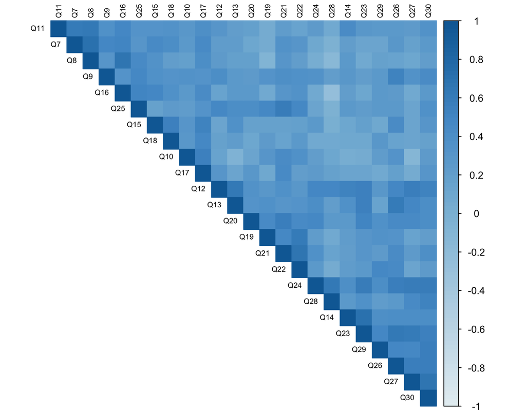

```r
X <- data[, 7:30]
for(i in 1:ncol(X)) X[is.na(X[,i]), i] <- mean(X[,i], na.rm = TRUE)
M <- cor(as.matrix(X))
col_palette <- colorRampPalette(c("#E6F0F3", "#BDD7E7", "#8CBEDB", "#539ACF", "#0D6BA4"))(100)
corrplot(M, type = "upper", order = "hclust", col = col_palette,
         tl.col = "black", tl.cex = 0.6, method = "color")
```

**Interprétation :** La matrice révèle plusieurs groupes de variables fortement corrélées (blocs bleus intenses). Cette structure confirme la pertinence de l’ACP : il existe des dimensions latentes à extraire.

## Choix du nombre d’axes

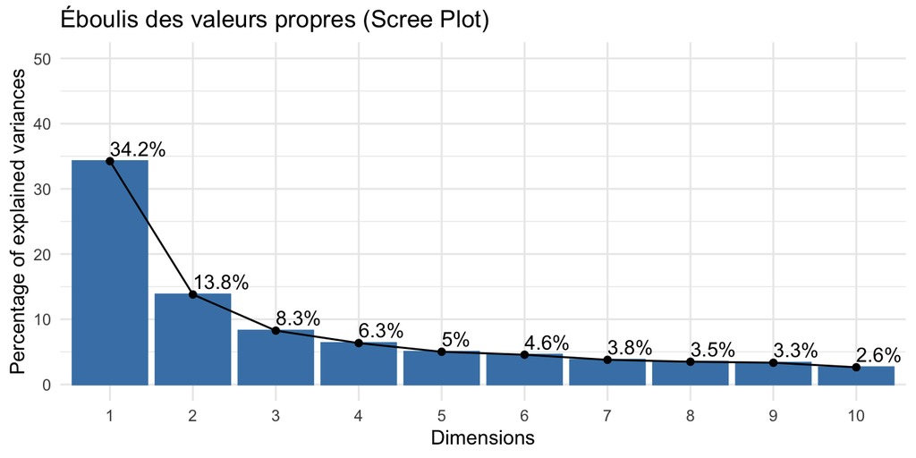

```r
p_scree <- fviz_eig(res.pca, addlabels = TRUE, ylim = c(0, 50)) +
  theme_minimal() +
  labs(title = "Éboulis des valeurs propres (Scree Plot)")

print(p_scree)
```

```r
kable(round(res.pca$eig[1:6, ], 3), caption = "Valeurs propres et taux d'inertie (6 premiers axes)")
```

Valeurs propres et taux d’inertie (6 premiers axes)

|  | eigenvalue | percentage of variance | cumulative percentage of variance |
| --- | --- | --- | --- |
| comp 1 | 8.220 | 34.248 | 34.248 |
| comp 2 | 3.312 | 13.801 | 48.049 |
| comp 3 | 1.981 | 8.255 | 56.305 |
| comp 4 | 1.524 | 6.349 | 62.654 |
| comp 5 | 1.203 | 5.014 | 67.668 |
| comp 6 | 1.095 | 4.563 | 72.230 |

**Décision :** Nous retenons les **2 premiers axes** pour les représentations graphiques.

## Cercle des corrélations des variables

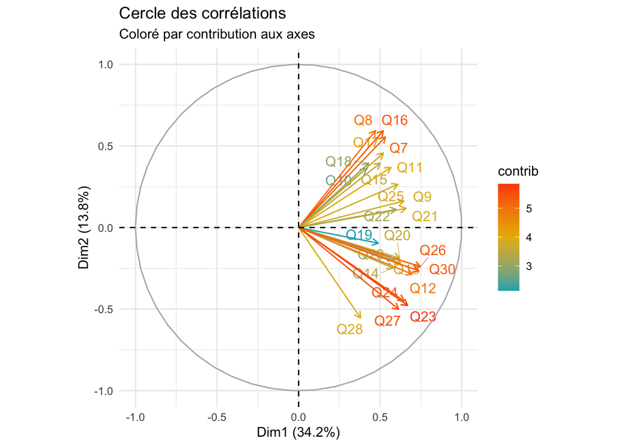

```r
fviz_pca_var(res.pca, col.var = "contrib",
             gradient.cols = c("#00AFBB", "#E7B800", "#FC4E07"),
             repel = TRUE) +
  theme_minimal() +
  labs(title = "Cercle des corrélations", subtitle = "Coloré par contribution aux axes")
```

**Interprétation :** L’axe 1 (**Adhésion Algorithmique**) est lié aux variables de satisfaction globale. L’axe 2 (**Exploration vs Exploitation**) oppose les variables liées à la découverte de nouveaux contenus à celles liées à la précision des recommandations.

## Carte des individus

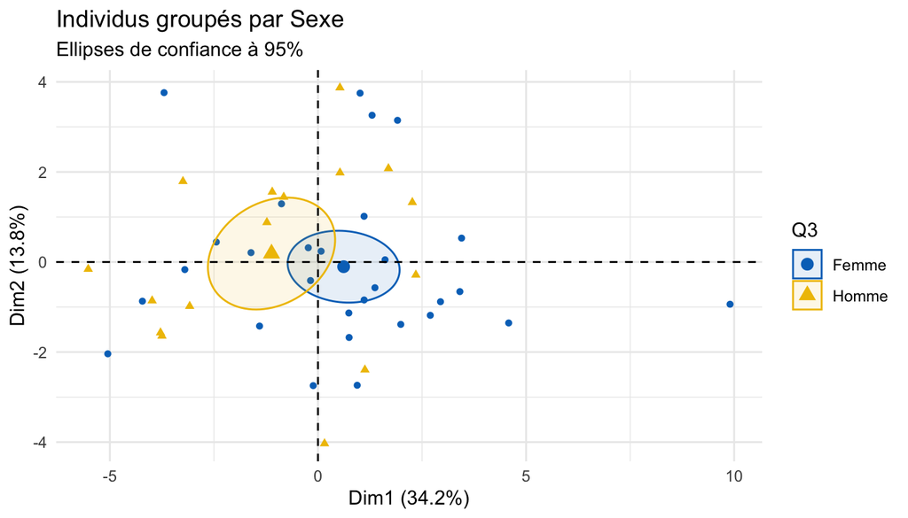

```r
fviz_pca_ind(res.pca,
             habillage = 3,
             addEllipses = TRUE,
             ellipse.type = "confidence",
             geom = "point",
             palette = "jco") +
  theme_minimal() +
  labs(title = "Individus groupés par Sexe", subtitle = "Ellipses de confiance à 95%")
```

**Conclusion ACP :** Le genre ne constitue pas un facteur de discrimination massif (chevauchement des ellipses). La diversité de perceptions dans l’échantillon suggère que d’autres variables (fréquence, plateforme) jouent un rôle plus structurant.

## Carte des individus (qualité de représentation)

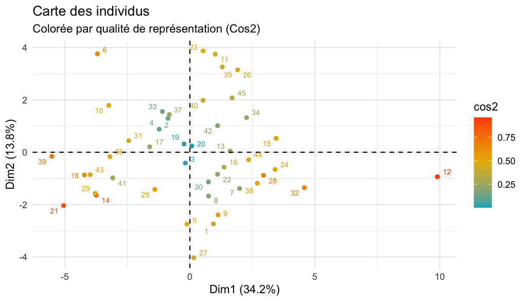

```r
fviz_pca_ind(res.pca,
             geom = c("point", "text"),
             col.ind = "cos2",
             gradient.cols = c("#00AFBB", "#E7B800", "#FC4E07"),
             repel = TRUE, labelsize = 2.5) +
  theme_minimal() +
  labs(title = "Carte des individus", subtitle = "Colorée par qualité de représentation (Cos2)")
```

**Interprétation :** Les individus en rouge sont ceux dont les coordonnées sur le plan factoriel sont les plus fiables. Ceux en bleu pâle sont moins bien représentés et doivent être interprétés avec prudence.

# Analyse en Correspondances Multiples (ACM)

L’ACM est l’équivalent de l’ACP pour les variables qualitatives. Elle permet d’étudier les liens entre les modalités des variables nominales et comportements binaires (Q31–Q35).

```r
res.mca <- MCA(data[, c(2:5, 31:35)], graph = FALSE)
```

## Nuage des modalités et des variables

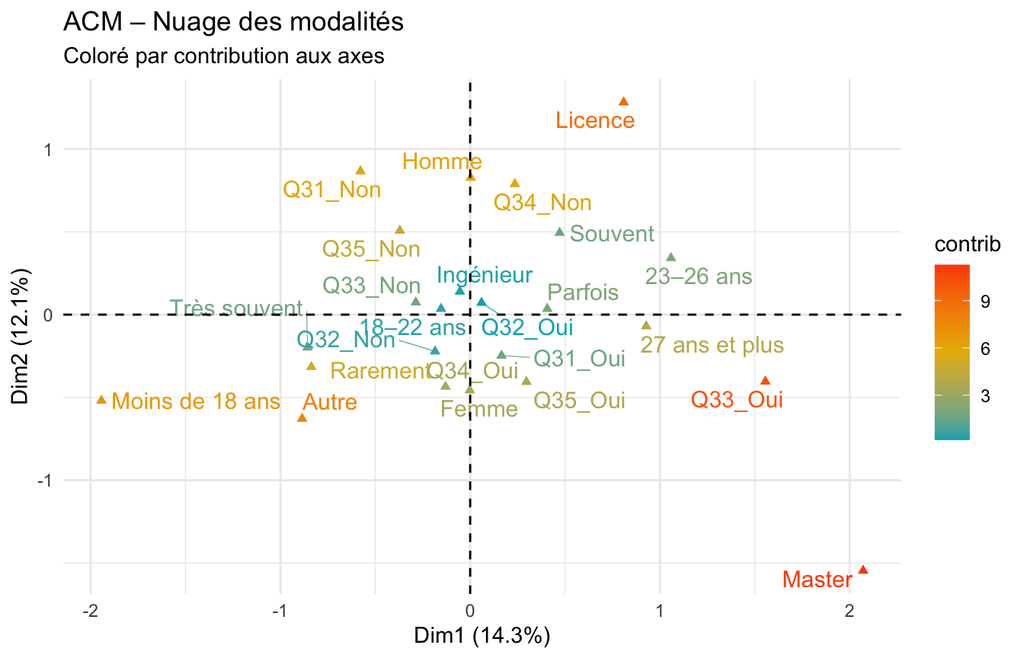

```r
fviz_mca_var(res.mca, col.var = "contrib",
             gradient.cols = c("#00AFBB", "#E7B800", "#FC4E07"),
             repel = TRUE) +
  theme_minimal() +
  labs(title = "ACM – Nuage des modalités", subtitle = "Coloré par contribution aux axes")
```

# Classification Hiérarchique sur Composantes Principales (HCPC)

L’HCPC combine les méthodes factorielles (réduction du bruit) et la classification ascendante hiérarchique pour produire des groupes stables.

```r
res.hcpc <- HCPC(res.pca, nb.clust = -1, graph = FALSE)
```

## Dendrogramme et Carte des clusters

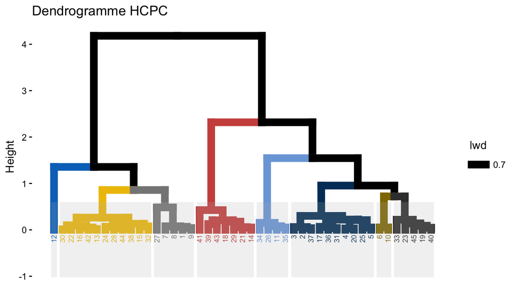

```r
fviz_dend(res.hcpc, rect = TRUE, palette = "jco", rect_fill = TRUE, cex = 0.5) +
  labs(title = "Dendrogramme HCPC")
```

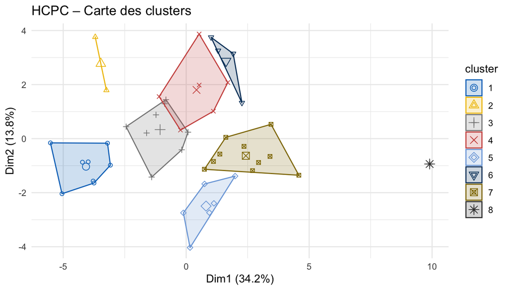

```r
fviz_cluster(res.hcpc, repel = TRUE, palette = "jco", geom = "point",
             main = "HCPC – Carte des clusters") +
  theme_minimal()
```

## Synthèse des Profils Identifiés

```r
kable(round(res.hcpc$desc.var$test.chi2, 3),
      caption = "Variables discriminantes par cluster (Khi-2)")
```

Variables discriminantes par cluster (Khi-2)

|  | p.value | df |
| --- | --- | --- |
| Q31 | 0.004 | 7 |
| Q4 | 0.033 | 21 |

[output not shown]

## Pouvoir discriminant des variables

```r
eta2_df <- as.data.frame(res.hcpc$desc.var$test.chi2)
kable(round(eta2_df, 3), caption = "Pouvoir discriminant des variables (Khi-2 et p-value)")
```

Pouvoir discriminant des variables (Khi-2 et p-value)

|  | p.value | df |
| --- | --- | --- |
| Q31 | 0.004 | 7 |
| Q4 | 0.033 | 21 |

# Partitionnement par K-means

## Nombre optimal de clusters (Méthode de la Silhouette)

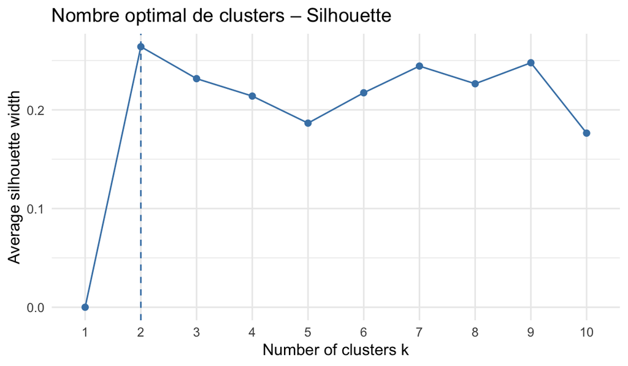

```r
fviz_nbclust(res.pca$ind$coord, kmeans, method = "silhouette") +
  theme_minimal() +
  labs(title = "Nombre optimal de clusters – Silhouette")
```

## Visualisation K-means (k = 3)

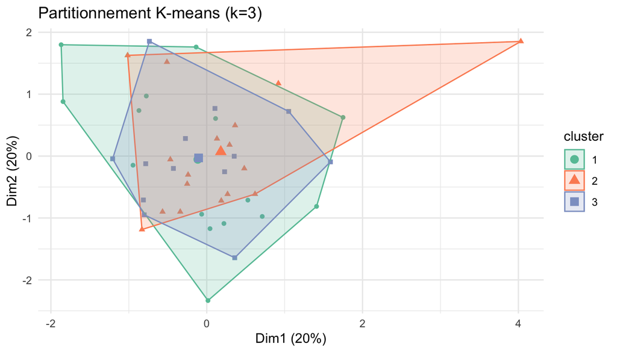

```r
set.seed(123)
res.km <- eclust(res.pca$ind$coord, "kmeans", k = 3, graph = FALSE)

fviz_cluster(res.km, palette = "Set2", geom = "point",
             ellipse.type = "convex",
             main = "Partitionnement K-means (k=3)") +
  theme_minimal()
```

# Conclusion Générale et Recommandations

## Limites et Perspectives

Cette étude porte sur **45 individus**, principalement jeunes et étudiants. Une extension à une population plus diverse permettrait de généraliser ces résultats. L’intégration de métriques comportementales réelles (temps de session, taux de clic) permettrait de confronter perceptions et comportements effectifs.